# nma

Charles T. Gray

09-06-2020

```r
# packages used in this blogpost

# general purpose
library(tidyverse)
library(kableExtra) # tables
library(skimr) # summary
library(patchwork) # vis + vis

# toolchain walkthrough
library(multinma) # network meta-analysis
library(nmathresh) # threshold analysis
library(metafor) # for (non network) meta-analysis

# special purpose
library(fdrtool) # for halfnormal distribution
library(simeta) # borrowing some handy functions
# note: should port these to my helper functions pkg

# for reproducibility
set.seed(40)
```

# 1 Introduction

Network meta-analysis is a statistical method for aggregating multiple pairwise comparisons on a response of interest. For example, perhaps three studies propose different treatments for a particular medical condition, network meta-analysis enables us to indirectly compare the treatments’ effect. Network meta-analysis is a technique for identifying *which* treatments are more effective than others, rather than *whether* a treatment is effective (Harrer et al. 2019).

There are several vignettes provided by the package `multinma::` (Phillippo et al. 2020), prompting many questions. What different techniques do the vignettes demonstrate? How to perform an nma? And what is the underlying theory?

However, as this is a first deep dive into network meta-analysis, I will restrict myself to the goals:

1. Provide an opinionated toolchain walkthrough of network meta-analysis.
2. Interpret the results using threshold analysis.

# 2 Thinking through the theory

In order to interpret the results produced by the algorithms provided by the packages investigated in this post, I need to ensure I have the conceptual understanding of the computational output.

Meta-analysis is a ultimately a form of regression, finding a line of best fit through the data. How this equation is solved is not the focus here, but, instead, unpacking the equational structure of a network meta-analysis, starting from linear regression.

## 2.1 meta-analysis

A meta-analysis is a special type of linear regression, wherein the response may be thought of as a [linear combination](https://en.wikipedia.org/wiki/Linear_combination) (a construction from set of terms multiplying each term by a constant and adding the results).

In a simple case of linear regression, we assume the response of interest, $y$, may be thought of in terms of grand mean $\beta_0$ and a covariate $x$ with coeffecicient $\beta_1$,

$$y = \beta_0 + \beta_1 x.$$

and that observations $y_i$ differ slightly from this overall response effect by some sampling error, $\varepsilon \sim N(0, \sigma^2)$, so that, for the $i$th observation, we have
$$y_i = B_0 + B_1 x + \varepsilon_i.$$
Where multiple covariates are to be considered, this construction is generalised to the matrix formula,
$$\mathbf y = \mathbf {X\beta} + \mathbf{\varepsilon}.$$
In a random effects model, instead of a coeffecient, a random effect is a term added to the equation that carries its own distribution, similar to the sampling error $\varepsilon$.

A simplest case of a random-effects meta-analysis, without covariates we wish to control the response by, we consider $k = 1, ..., K$ studies’ obesrvations in terms of a grand mean across studies, $\mu$ (taking the role of $\beta_0$ above), with a study-specific adjustment, $\theta_k \sim N(0, \tau^2)$, so that the observation for the $k$th study we have
$$y_k = \mu + \theta_k + \varepsilon_k,$$
with sampling error $\varepsilon_k \sim N(0, \sigma_k^2)$.

Note the error, $\varepsilon_k$, for the $k$th study is attributed an associated study-specific variance, $\sigma_k^2$, whereas $\tau^2$, the variance of $\theta_k$ is an aggregate measure of variation across all studies.

Meta-analysis model can be extended to meta-regression, with the addition of covariates, as with standard linear regression,
$$y_k = \mu + \theta_k + \mathbf {\beta_k X} + \epsilon_k.$$
That is,

$$\begin{array}{rcl}
Y_k &\sim& N(\mu + \theta_k + \beta_kX, \sigma_k^2)\\
\theta_k &\sim& N(0, \tau^2)
\end{array}$$

And, if $\beta_k$ are random, these, too, would have distributions.

To further complicate matters, a meta-analysis is often a **pairwise comparison** between two groups, a control and and intervention group, with the central question, what is the difference in effect between the two groups across all studies? In this case, the response $y_k$, the aggregated effect $\mu$, and the random effect for variation of this study, $\theta_k$, all measure a pairwise comparison. The pairwise comparison chosen depends on the context of the response variable in question, such as a standardised mean difference (Cohen’s $d$), or a bias-adjusted $d$ (Hedge’s $g$), for continuous response variables. Similarly, for binary data, an appropriate measure of risk or odds ratios may be chosen (Borenstein et al. 2011).

In the interests of brevity, I’m not labouring the distinction between fixed and random covariates, but I’m sure my understanding could be clearer. This, however, seems a sufficient point from which to further my understanding of network meta-analysis.

I find this statistical nomenclature confusing. The random effect for the study, $\theta_k$, *is* a coefficient, as it is indexed by $k$. This is a coefficient for a dummy variable $z_k$ that indicates the study,
$$z_k = \begin{cases}
1 & \text{if } k = k\\
0 & \text{if } k \neq k
\end{cases}$$

So, we always have $y$ in terms of linear combination of $z$ and $x$ where we care about one variable $z$, and wish to control for the others $x$.
$$y_k = \mu + \gamma_k z + \beta_k x + \varepsilon_k$$

## 2.2 network meta-analysis

Now, in network meta-analysis we have more than one treatment. The general idea is that we combine pairwise direct comparisons to form an indirect comparison.

Starting with the simplest case of combining two pairwise comparisons, a think of this is with treatments A, B, and C (Lumley 2002). We denote $\delta_{XY}$ as the comparison between X and Y, with a positive value of $\delta$ indicating a higher outcome for Y than X, and a negative value of $\delta$ indicates a lower outcome for Y than X. If we have direct comparisons $\delta_{AC}$ and $\delta_{CB}$, we can construct an indirect comparison of differences.
$$\delta_{AB} = \delta_{AC} + \delta_{CB}$$
Continuing along with Lumley, we let $i$ and $j$ denote treatments compared by $Y_{ij}$. Since $i$ and $j$ have average true effects $\mu_i$ and $\mu_j$, we have $\delta_{ij} = \mu_i - \mu_j$. Where there was one random effect for the heterogeneity of treatment effect in a standard meta-analysis, there are now two random effects, $\eta_{ik}$ and $\eta_{jk}$ with variance $\tau^2$, for the difference betwteen the average effects of treatments $i$ and $j$ in this study. Another random effect $\zeta_{ij}$ is added to capture ‘the inconsistency of this pair of treatments with the rest of the evidence’. The *incoherence* of the network is $\omega = \text{var}(\zeta)$. With these we have the formal model.

$$\begin{array}{rcl}
Y_{ijk} &\sim& \text{N}(\mu_i - \mu_j + \eta_{ik} + \eta_{jk} + \zeta_{ij}, \sigma^2_{ijk})\\
\eta_{ij} &\sim& N(0, \tau^2)\\
\zeta_{ij} &\sim& N(0, \omega)
\end{array}$$

# 3 Example: Mean off-time reduction in Parkinson’s disease

Now, for an example of a dataset that has network with at least three nodes.

```r
vignette("example_parkinsons", "multinma")
```

Find out how many nodes are in this network.

```r
parkinsons %>%
  # extract treatment variable
  pull(trtn) %>%
  # count distinct treatment types
  n_distinct()
```

```
## [1] 5
```

## 3.1 Parkisons dataset

This vignette uses the `parkinsons` dataset.

```r
# take a look at the data
parkinsons %>% head()
```

```
##   studyn trtn     y    se   n  diff se_diff
## 1      1    1 -1.22 0.504  54    NA   0.504
## 2      1    3 -1.53 0.439  95 -0.31   0.668
## 3      2    1 -0.70 0.282 172    NA   0.282
## 4      2    2 -2.40 0.258 173 -1.70   0.382
## 5      3    1 -0.30 0.505  76    NA   0.505
## 6      3    2 -2.60 0.510  71 -2.30   0.718
```

```r
parkinsons %>% str()
```

```
## 'data.frame':    15 obs. of  7 variables:
##  $ studyn : int  1 1 2 2 3 3 3 4 4 5 ...
##  $ trtn   : num  1 3 1 2 1 2 4 3 4 3 ...
##  $ y      : num  -1.22 -1.53 -0.7 -2.4 -0.3 -2.6 -1.2 -0.24 -0.59 -0.73 ...
##  $ se     : num  0.504 0.439 0.282 0.258 0.505 0.51 0.478 0.265 0.354 0.335 ...
##  $ n      : num  54 95 172 173 76 71 81 128 72 80 ...
##  $ diff   : num  NA -0.31 NA -1.7 NA -2.3 -0.9 NA -0.35 NA ...
##  $ se_diff: num  0.504 0.668 0.282 0.382 0.505 0.718 0.695 0.265 0.442 0.335 ...
```

Checking `?parkinsons` documentation, have a study variable `studyn`, a treatment variable `trtn`, a measure of effect `y`, and standard error of the effect, `se`, sample size `n`.

There is also the mean difference of the treatment in the reference arm `diff`, and the standard error of the mean difference `se_diff`. This provides three ways of meta-analysing the data.

> This dataset may be analysed using either an arm-based likelihood using y and se, or a contrast-based likelihood using diff and se_diff (or a combination of the two across different studies) (Phillippo et al. 2020).

In this case, we have a continuous response variable.

## 3.2 Network meta-analysis model

Since `multinma::` provides tools for Bayesian network meta-analysis, we have the following model structure
$$\boldsymbol y_{.jk} = \pi_\text{Agg}(\boldsymbol\theta_{.jk}),\\
g(\boldsymbol\theta_{.jk}) = \boldsymbol\mu_j + \boldsymbol\delta_{jk}$$

Now to apply this structure to the data we have in `parkinsons`.

For an arm-based network meta-analysis, begin by converting the raw data to a network object.

```r
arm_net <-
  set_agd_arm(
    parkinsons,
    study = studyn,
    trt = trtn,
    y = y,
    se = se,
    sample_size = n
  )

# this is a network object
class(arm_net)
```

```
## [1] "nma_data"
```

Now that we have a network object, we can inspect the relationships between the treatments where studies provide comparisons. Here we see there are pairwise comparisons between many of the treatments. In particular, treatment 3 and treatment 5 have not been compared directly, nor have treatment 2 and treatment 3.

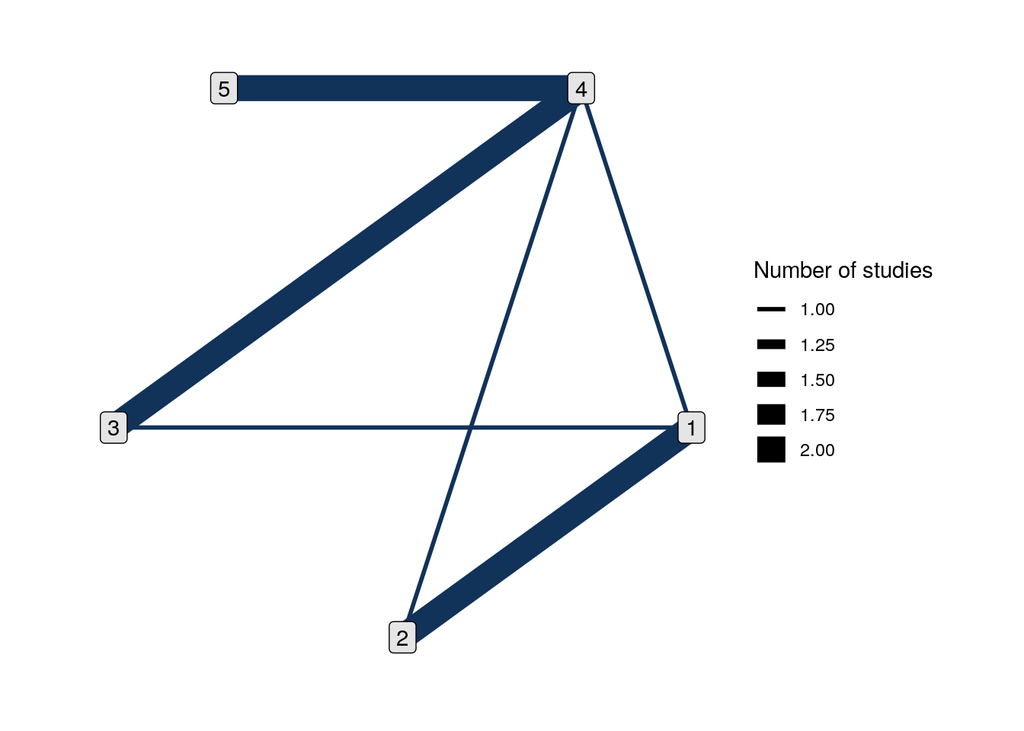

```r
plot(arm_net)
```

The number of studies measure must be relational.

# References

Borenstein, Michael, Larry V. Hedges, Julian P. T. Higgins, and Hannah R. Rothstein. 2011. *Introduction to Meta-Analysis*. John Wiley & Sons. http://books.google.com?id=JQg9jdrq26wC.

Harrer, Mathias, Prof Dr Pim Cuijpers², Prof Dr Toshi A. Furukawa³, and Assoc Prof Dr David D. Ebert². 2019. *Doing Meta-Analysis in R*. https://bookdown.org/MathiasHarrer/Doing_Meta_Analysis_in_R/.

Lumley, Thomas. 2002. “Network Meta-Analysis for Indirect Treatment Comparisons.” *Statistics in Medicine* 21 (16): 2313–24. https://doi.org/10.1002/sim.1201.

Phillippo, David M., Sofia Dias, A. E. Ades, Mark Belger, Alan Brnabic, Alexander Schacht, Daniel Saure, Zbigniew Kadziola, and Nicky J. Welton. 2020. “Multilevel Network Meta-Regression for Population-Adjusted Treatment Comparisons.” *Journal of the Royal Statistical Society: Series A (Statistics in Society)* 183 (3): 1189–1210. https://doi.org/10.1111/rssa.12579.